# Correlation Plots & Ridge/Lasso Modeling Rounds Plots

Cassandra Sperow

2023-11-12

- Note: The first several correlation plots relate to exploratory data analysis while other sections towards the end relate to post-modeling analysis with the predictors from 2 rounds of Ridge & Lasso modeling (See 2 Rmd files with Ridge and Lasso in title). The Ridge & Lasso Modeling 2.Rmd is the final results of modeling Clade C vs. non-Clade C.

# Clade C

```r
read_csv("../output/lr_data.csv") %>%
  mutate(Clade = as.factor(Clade)) -> lr_data
head(lr_data)
```

```
## # A tibble: 6 × 3,228
##   sample_id  Clade ASV1236 ASV0421 ASV0691 ASV0899 ASV1004 ASV1041 ASV1058
##   <chr>      <fct>   <dbl>   <dbl>   <dbl>   <dbl>   <dbl>   <dbl>   <dbl>
## 1 SKAU-R2-23 1           0       0       0       0       0       0       0
## 2 SWAJ-R4-3  0           0       0       0       0       0       0       0
## 3 SYAN-R3-19 1           0       0       0       0       0       0       0
## 4 PMAQ-R2-19 0           0       0       0       0       0       0       0
## 5 SDOG-R3-6  0           0       0       0       0       0       0       0
## 6 PDOG-R2-22 0         234     147      90     103      60      42      49
## # ℹ 3,219 more variables: ASV12542 <dbl>, ASV1294 <dbl>, ASV13113 <dbl>,
## #   ASV1318 <dbl>, ASV2269 <dbl>, ASV2542 <dbl>, ASV2660 <dbl>, ASV2737 <dbl>,
## #   ASV2840 <dbl>, ASV3053 <dbl>, ASV3077 <dbl>, ASV3134 <dbl>, ASV3140 <dbl>,
## #   ASV3579 <dbl>, ASV6119 <dbl>, ASV7557 <dbl>, ASV8422 <dbl>, ASV1086 <dbl>,
## #   ASV1310 <dbl>, ASV15750 <dbl>, ASV16905 <dbl>, ASV2033 <dbl>,
## #   ASV2089 <dbl>, ASV2127 <dbl>, ASV2725 <dbl>, ASV2804 <dbl>, ASV3075 <dbl>,
## #   ASV3327 <dbl>, ASV3342 <dbl>, ASV3532 <dbl>, ASV3600 <dbl>, …
```

# Correlation Matrix - Clade C - All

```r
cor_matrix_lr_data <- cor(lr_data[,-c(1,2)]) # 3226
```

## Correlation Matrix - Top 20

```r
cor_matrix_lr_data[1:20,1:20]
```

```
##             ASV1236   ASV0421    ASV0691   ASV0899    ASV1004    ASV1041
## ASV1236  1.00000000 0.4719489 0.33328413 0.4345430 0.63954876 0.35284766
## ASV0421  0.47194889 1.0000000 0.13025974 0.3065858 0.36640762 0.70640441
## ASV0691  0.33328413 0.1302597 1.00000000 0.9330727 0.13689647 0.04780135
## ASV0899  0.43454301 0.3065858 0.93307271 1.0000000 0.24258443 0.22367350
## ASV1004  0.63954876 0.3664076 0.13689647 0.2425844 1.00000000 0.23842644
## ASV1041  0.35284766 0.7064044 0.04780135 0.2236735 0.23842644 1.00000000
## ASV1058  0.59173881 0.2059648 0.37736380 0.3910734 0.81417820 0.20430536
## ASV12542 0.91386405 0.3555057 0.23008338 0.3211568 0.63350453 0.29250721
## ASV1294  0.61030497 0.3612280 0.72483382 0.8587672 0.40101510 0.27306753
## ASV13113 0.92728974 0.3071571 0.23444591 0.3139745 0.64343968 0.27225068
## ASV1318  0.93713305 0.4029379 0.22829747 0.3343773 0.66743766 0.31346237
## ASV2269  0.92809113 0.3077736 0.23492898 0.3145436 0.64417512 0.27274159
## ASV2542  0.96002759 0.5169371 0.22135432 0.3324094 0.66689907 0.38088439
## ASV2660  0.08791607 0.3431455 0.19622735 0.2810795 0.05484159 0.14822009
## ASV2737  0.27038644 0.1532740 0.79764881 0.8088644 0.08028114 0.07192148
## ASV2840  0.80457172 0.4531931 0.19833817 0.3267227 0.58490739 0.37015977
## ASV3053  0.91726472 0.6661780 0.19339045 0.3243255 0.63806025 0.44976749
## ASV3077  0.56971901 0.2623945 0.27818646 0.1898965 0.39201667 0.20231604
## ASV3134  0.36761752 0.1521544 0.08283074 0.1220394 0.24861896 0.20989789
## ASV3140  0.87442688 0.2553189 0.51710942 0.6058170 0.54284001 0.22710196
##             ASV1058  ASV12542   ASV1294   ASV13113   ASV1318    ASV2269
## ASV1236  0.59173881 0.9138641 0.6103050 0.92728974 0.9371331 0.92809113
## ASV0421  0.20596482 0.3555057 0.3612280 0.30715710 0.4029379 0.30777363
## ASV0691  0.37736380 0.2300834 0.7248338 0.23444591 0.2282975 0.23492898
## ASV0899  0.39107337 0.3211568 0.8587672 0.31397452 0.3343773 0.31454359
## ASV1004  0.81417820 0.6335045 0.4010151 0.64343968 0.6674377 0.64417512
## ASV1041  0.20430536 0.2925072 0.2730675 0.27225068 0.3134624 0.27274159
## ASV1058  1.00000000 0.5673906 0.4696889 0.57653293 0.5695280 0.57726151
## ASV12542 0.56739058 1.0000000 0.5643634 0.98443519 0.9798148 0.98519393
## ASV1294  0.46968895 0.5643634 1.0000000 0.55363574 0.5829964 0.55432994
## ASV13113 0.57653293 0.9844352 0.5536357 1.00000000 0.9840521 0.99925437
## ASV1318  0.56952800 0.9798148 0.5829964 0.98405211 1.0000000 0.98484068
## ASV2269  0.57726151 0.9851939 0.5543299 0.99925437 0.9848407 1.00000000
## ASV2542  0.56046220 0.9395121 0.5524149 0.95308973 0.9671892 0.95384923
## ASV2660  0.04674737 0.2508043 0.4088380 0.09853055 0.1466671 0.09879182
## ASV2737  0.34588890 0.1939770 0.5378356 0.14250868 0.1562469 0.14286576
## ASV2840  0.50924129 0.9340482 0.5566464 0.86839809 0.8918856 0.86914952
## ASV3053  0.50432564 0.8287271 0.5101428 0.84082124 0.8794572 0.84152483
## ASV3077  0.56569615 0.5743408 0.3273798 0.58299387 0.5848931 0.58355919
```

[output cut: 29 more lines]

```
## ASV1041  0.20989789 0.22710196
## ASV1058  0.24059144 0.66212253
## ASV12542 0.39359119 0.83578893
## ASV1294  0.21741324 0.71549951
## ASV13113 0.39990400 0.84800748
## ASV1318  0.39235180 0.83503077
## ASV2269  0.40040107 0.84872319
## ASV2542  0.38016049 0.80881848
## ASV2660  0.03271083 0.08098915
## ASV2737  0.04806126 0.55178784
## ASV2840  0.37663785 0.73609272
## ASV3053  0.33416980 0.71306207
## ASV3077  0.22890657 0.49329678
## ASV3134  1.00000000 0.33680566
## ASV3140  0.33680566 1.00000000
```

```r
png(filename = "../plots/top20_corr_clade_c.png",
    width = 1200, height = 800)

library(corrplot)
top20_corr_clade_c <- corrplot(cor_matrix_lr_data[1:20, 1:20],
                               method = "circle")
```

## Correlation Matrix - Top 50

- Anything over 50 gets small and hard to read

```r
png(filename = "../plots/top50_corr_clade_c.png",
    width = 1200, height = 800)

library(corrplot)
top50_corr_clade_c <- corrplot(cor_matrix_lr_data[1:50, 1:50],
                               method = "circle")
```

# From Lasso Regression with Clade as Binary Outcome, ASV00013 was kept in the model

```r
# read in taxonomy table to see which bacterium this is
read_delim("../data/Files/16S_tax.txt") -> bac_tax
bac_tax %>%
  filter(ASV == "ASV0013") %>%
  pivot_longer(cols = everything())
```

```
## # A tibble: 8 × 2
##   name    value
##   <chr>   <chr>
## 1 ASV     ASV0013
## 2 Kingdom Bacteria
## 3 Phylum  Proteobacteria
## 4 Class   Gammaproteobacteria
## 5 Order   Oceanospirillales
## 6 Family  Endozoicomonadaceae
## 7 Genus   Endozoicomonas
## 8 Species <NA>
```

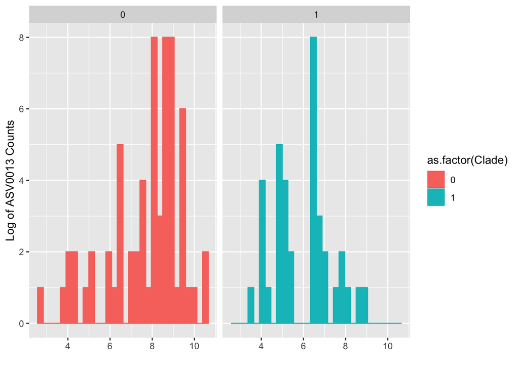

```r
#plot(log(lr_data$ASV0013), lr_data$Clade)

ggplot(lr_data, aes( y = log(ASV0013), color = as.factor(Clade), fill = as.factor(Clade))) +
  geom_histogram() +
  coord_flip() +
  facet_wrap(~Clade) +
  xlab("Log of ASV0013 Counts") +
  ylab("")
```

# Correlation Plot - Both Species - All Data

```r
read_csv("../output/rev_coral_join.csv") -> rev_coral_join
# correlation matrix
corr_matrix_all <- cor(rev_coral_join[,-c(1:8)])

corr_matrix_all[1:20,1:20]
```

```
##              ASV0001     ASV0002     ASV0003      ASV0004      ASV0005
## ASV0001  1.000000000 -0.21271296 -0.19706030 -0.170870440  0.005999820
## ASV0002 -0.212712959  1.00000000 -0.07519482  0.412946601 -0.217728218
## ASV0003 -0.197060299 -0.07519482  1.00000000 -0.064257395 -0.187006206
## ASV0004 -0.170870440  0.41294660 -0.06425739  1.000000000 -0.145636598
## ASV0005  0.005999820 -0.21772822 -0.18700621 -0.145636598  1.000000000
## ASV0006  0.110621592 -0.24026275 -0.21163771 -0.204029577  0.389891211
## ASV0007  0.994414522 -0.20748386 -0.19416930 -0.164429426 -0.002496173
## ASV0008 -0.213877804  0.99589129 -0.07877746  0.416860874 -0.219199374
## ASV0009  0.993630263 -0.20597683 -0.19289322 -0.162876215 -0.004980980
## ASV0010  0.130959473 -0.17847576 -0.15514275 -0.178054929 -0.099444993
## ASV0011  0.079356406  0.01422047 -0.11215582 -0.047694736  0.090429292
## ASV0012 -0.213865555  0.99647487 -0.07863909  0.417777442 -0.219140252
## ASV0013 -0.196048417 -0.03535810  0.81639787  0.003265124 -0.188872334
## ASV0014 -0.200937200 -0.07075675  0.99326684 -0.055275143 -0.190172190
## ASV0015 -0.171653827  0.41317070 -0.06585546  0.994174829 -0.152987075
## ASV0016 -0.201161244 -0.06973791  0.99404200 -0.054012676 -0.190556978
## ASV0017 -0.172297597  0.41657852 -0.06518828  0.995026484 -0.154318204
## ASV0018  0.009033656 -0.21806579 -0.18715107 -0.148496105  0.988668582
## ASV0019  0.010049846 -0.21804293 -0.18713478 -0.148365549  0.989244744
## ASV0020  0.079432989 -0.12129033 -0.10225583 -0.097078669  0.316695858
##             ASV0006      ASV0007      ASV0008      ASV0009     ASV0010
## ASV0001  0.11062159  0.994414522 -0.213877804  0.993630263  0.13095947
## ASV0002 -0.24026275 -0.207483864  0.995891291 -0.205976831 -0.17847576
## ASV0003 -0.21163771 -0.194169305 -0.078777459 -0.192893218 -0.15514275
## ASV0004 -0.20402958 -0.164429426  0.416860874 -0.162876215 -0.17805493
## ASV0005  0.38989121 -0.002496173 -0.219199374 -0.004980980 -0.09944499
## ASV0006  1.00000000  0.112175579 -0.241774451  0.113419351  0.13387745
## ASV0007  0.11217558  1.000000000 -0.208366925  0.999521316  0.13294081
## ASV0008 -0.24177445 -0.208366925  1.000000000 -0.206882982 -0.17981310
## ASV0009  0.11341935  0.999521316 -0.206882982  1.000000000  0.13471755
## ASV0010  0.13387745  0.132940807 -0.179813102  0.134717549  1.00000000
## ASV0011  0.07049896  0.076594733  0.009967101  0.074600787  0.01689247
## ASV0012 -0.24200917 -0.208363316  0.999827225 -0.206878715 -0.17990739
## ASV0013 -0.21457923 -0.192607792 -0.039335290 -0.191451885 -0.15952858
## ASV0014 -0.21585171 -0.197891733 -0.073121244 -0.196625123 -0.15852442
## ASV0015 -0.20562040 -0.164229163  0.421997437 -0.162656889 -0.17724957
## ASV0016 -0.21623871 -0.198119839 -0.072203040 -0.196846895 -0.15873670
## ASV0017 -0.20678997 -0.164877163  0.425014463 -0.163292593 -0.17798867
## ASV0018  0.38543803  0.003767043 -0.219542044  0.001184209 -0.09830622
```

[output cut: 29 more lines]

```
## ASV0006 -0.21623871 -0.206789967  0.385438035  0.387548595  0.10814837
## ASV0007 -0.19811984 -0.164877163  0.003767043  0.004649903  0.06965012
## ASV0008 -0.07220304  0.425014463 -0.219542044 -0.219518739 -0.12207695
## ASV0009 -0.19684690 -0.163292593  0.001184209  0.002086428  0.06655624
## ASV0010 -0.15873670 -0.177988674 -0.098306221 -0.097415382 -0.03752435
## ASV0011 -0.11368991 -0.048148370  0.089231191  0.090101465  0.01238370
## ASV0012 -0.07209242  0.425734545 -0.219482600 -0.219459303 -0.12204632
## ASV0013  0.84027975  0.003905875 -0.188933211 -0.188893623 -0.10040233
## ASV0014  0.99958573 -0.054762334 -0.190284219 -0.190268364 -0.10372046
## ASV0015 -0.05435111  0.999726169 -0.153635072 -0.153550917 -0.09755587
## ASV0016  1.00000000 -0.053623572 -0.190679416 -0.190664309 -0.10407991
## ASV0017 -0.05362357  1.000000000 -0.155034605 -0.154925142 -0.09826013
## ASV0018 -0.19067942 -0.155034605  1.000000000  0.999682524  0.33191426
## ASV0019 -0.19066431 -0.154925142  0.999682524  1.000000000  0.33187976
## ASV0020 -0.10407991 -0.098260127  0.331914260  0.331879762  1.00000000
```

```r
# save the png
png(filename = "../plots/corr_plot_top_20.png",
    width = 1200, height = 900)

# correlation plot
library(corrplot)
corr_plot_top_20 <- corrplot(corr_matrix_all[1:20, 1:20],
                               method = "circle",
                             )
```

```r
# save the png
png(filename = "../plots/corr_plot_top_100.png",
    width = 1200, height = 900)

# correlation plot
library(corrplot)
corr_plot_top_100 <- corrplot(corr_matrix_all[1:100, 1:100],
                               method = "circle",
                              )
```

```r
# save the png
png(filename = "../plots/corr_plot_top_50.png",
    width = 1200, height = 900)

# correlation plot
library(corrplot)
corr_plot_top_50 <- corrplot(corr_matrix_all[1:50, 1:50],
                               method = "circle",
                              )
```

# Ridge modeling coefficients for ‘best’ model

```r
read_csv("../output/ridge_500_coef_df.csv") -> ridge_results
ridge_results
```

```
## # A tibble: 501 × 3
##    row_names       s1 abs_coef
##    <chr>        <dbl>    <dbl>
##  1 ASV6296      2.30     2.30
##  2 ASV4003      1.69     1.69
##  3 ASV8219      1.41     1.41
##  4 ASV4449      1.33     1.33
##  5 (Intercept)  0.900    0.900
##  6 ASV0788      0.860    0.860
##  7 ASV7777     -0.859    0.859
##  8 ASV1238     -0.817    0.817
##  9 ASV3075      0.812    0.812
## 10 ASV3532     -0.715    0.715
## # ℹ 491 more rows
```

## Where are these ASVs in relation to one another?

```r
cor_matrix_lr_data %>% # data used in clade C modeling
  as.data.frame() %>%
  mutate(ASV = rownames(.), .before = ASV1236) %>%
 # filter(ASV %in% c(ridge_results$row_names)) %>%
  filter(ASV %in% c("ASV6296"   ,   "ASV4003"   ,"ASV8219"  ,   "ASV4449"   ) )
```

```
##             ASV    ASV1236     ASV0421      ASV0691     ASV0899     ASV1004
## ASV4003 ASV4003 0.06717484 -0.02296295  0.261682875  0.17301789 -0.02045591
## ASV8219 ASV8219 0.17219376 -0.01195569 -0.009448934 -0.01063832 -0.01065039
## ASV4449 ASV4449 0.14421211 -0.01639475 -0.012957255 -0.01458825 -0.01460480
## ASV6296 ASV6296 0.17219376 -0.01195569 -0.009448934 -0.01063832 -0.01065039
##              ASV1041     ASV1058     ASV12542     ASV1294     ASV13113
## ASV4003 -0.017591467 -0.02178976 -0.013076637  0.04700181 -0.012314997
## ASV8219 -0.009159016 -0.01134486 -0.006808365 -0.01075353 -0.006411816
## ASV4449 -0.012559693 -0.01555713 -0.009336262 -0.01474624 -0.008792478
## ASV6296 -0.009159016 -0.01134486 -0.006808365 -0.01075353 -0.006411816
##             ASV1318      ASV2269      ASV2542      ASV2660      ASV2737
## ASV4003 -0.01456920 -0.012053346 -0.013898868 -0.010523182  0.154171029
## ASV8219 -0.00758547 -0.006275588 -0.007236461 -0.005478906 -0.007385769
## ASV4449 -0.01040190 -0.008605668 -0.009923307 -0.007513184 -0.010128052
## ASV6296 -0.00758547 -0.006275588 -0.007236461 -0.005478906 -0.007385769
##             ASV2840      ASV3053      ASV3077      ASV3134      ASV3140
## ASV4003 -0.01561837 -0.013929913 -0.013511032 -0.014701503 -0.014352545
## ASV8219 -0.00813172 -0.007252624 -0.007034534 -0.007654353 -0.007472668
## ASV4449 -0.01115097 -0.009945471 -0.009646405 -0.010496359 -0.010247216
## ASV6296 -0.00813172 -0.007252624 -0.007034534 -0.007654353 -0.007472668
##              ASV3579      ASV6119      ASV7557      ASV8422      ASV1086
## ASV4003 -0.010436314 -0.012053346 -0.012053346 -0.014655295 -0.012822427
## ASV8219 -0.005433678 -0.006275588 -0.006275588 -0.007630295 -0.006676010
## ASV4449 -0.007451164 -0.008605668 -0.008605668 -0.010463368 -0.009154765
## ASV6296 -0.005433678 -0.006275588 -0.006275588 -0.007630295 -0.006676010
##              ASV1310     ASV15750     ASV16905      ASV2033      ASV2089
## ASV4003 -0.013836037 -0.009523929 -0.012053346 -0.016931316 -0.013411788
## ASV8219 -0.007203747 -0.004958644 -0.006275588 -0.008815308 -0.006982862
## ASV4449 -0.009878447 -0.006799753 -0.008605668 -0.012088368 -0.009575548
## ASV6296 -0.007203747 -0.004958644 -0.006275588 -0.008815308 -0.006982862
##              ASV2127     ASV2725      ASV2804      ASV3075      ASV3327
## ASV4003 -0.016804529  0.15404463 -0.012053346  0.112998567 -0.018227726
## ASV8219 -0.008749296 -0.01026592 -0.006275588 -0.007807928 -0.009490285
## ASV4449 -0.011997847 -0.01407758 -0.008605668 -0.010706956  0.162333575
## ASV6296 -0.008749296 -0.01026592 -0.006275588 -0.007807928 -0.009490285
##              ASV3342      ASV3532      ASV3600      ASV4013      ASV4136
## ASV4003  0.030764135 -0.011008689  0.147499580 -0.015092997 -0.013069248
## ASV8219 -0.006589651 -0.005731686 -0.009435827 -0.007858185 -0.006804518
## ASV4449 -0.009036342 -0.007859819 -0.012939282 -0.010775873 -0.009330987
## ASV6296 -0.006589651 -0.005731686 -0.009435827 -0.007858185 -0.006804518
```

[output cut: 3080 more lines]

```
##              ASV4159      ASV5084      ASV6584      ASV9614     ASV16068
## ASV4003 -0.010664618 -0.006933834 -0.006933834 -0.006933834 -0.006933834
## ASV8219 -0.005552545 -0.003610108 -0.003610108 -0.003610108 -0.003610108
## ASV4449 -0.007614164 -0.004950516 -0.004950516 -0.004950516 -0.004950516
## ASV6296 -0.005552545 -0.003610108 -0.003610108 -0.003610108 -0.003610108
##              ASV2141      ASV0395      ASV5640      ASV2854      ASV3825
## ASV4003 -0.009658279 -0.009640260 -0.007694666 -0.007911839 -0.014157786
## ASV8219 -0.005028593 -0.005019212 -0.004006236 -0.004119307 -0.007371267
## ASV4449 -0.006895674 -0.006882809 -0.005493722 -0.005648777 -0.010108165
## ASV6296 -0.005028593 -0.005019212 -0.004006236 -0.004119307 -0.007371267
##              ASV0481      ASV3304      ASV0445      ASV1845    ASV3110
## ASV4003 -0.008117569 -0.007984083 -0.010363032 -0.012057958 0.08941038
## ASV8219 -0.004226421 -0.004156921 -0.005395524 -0.006277989 0.41888232
## ASV4449 -0.005795661 -0.005700356 -0.007398843 -0.008608961 0.35731378
## ASV6296 -0.004226421 -0.004156921 -0.005395524 -0.006277989 0.41888232
```

- They are uncorrelated, and ridge would have chosen these because of this.

# Lasso modeling selection

```r
read_csv("../output/lasso_500_coef_df.csv") -> lasso_results
lasso_results
```

```
## # A tibble: 7 × 3
##   row_names        s1 abs_coef
##   <chr>         <dbl>    <dbl>
## 1 ASV0675      0.361    0.361
## 2 (Intercept)  0.284    0.284
## 3 ASV0013     -0.251    0.251
## 4 ASV0958      0.161    0.161
## 5 ASV0485      0.0498   0.0498
## 6 ASV0120     -0.0464   0.0464
## 7 ASV0011     -0.0146   0.0146
```

```r
cor_matrix_lr_data %>% # data used in clade C modeling
  as.data.frame() %>%
  mutate(ASV = rownames(.), .before = ASV1236) %>%
  filter(ASV %in% c("ASV0675"   ,   "ASV0013"   ,   "ASV0958"   ,   "ASV0485"))
```

```
##             ASV   ASV1236   ASV0421    ASV0691    ASV0899     ASV1004   ASV1041
## ASV0485 ASV0485 0.9687327 0.5977679 0.27410787 0.41493534 0.669814846 0.4348367
## ASV0675 ASV0675 0.3620170 0.2191712 0.30037861 0.27703581 0.228525083 0.1314686
## ASV0013 ASV0013 0.0181429 0.3383449 0.02971219 0.07839829 0.001161736 0.2667143
## ASV0958 ASV0958 0.6407035 0.5568222 0.21835211 0.30657917 0.435352299 0.2723858
##              ASV1058   ASV12542   ASV1294   ASV13113    ASV1318   ASV2269
## ASV0485  0.560249139 0.89463346 0.6050414 0.89720624 0.92924277 0.8980837
## ASV0675  0.247976890 0.30066923 0.2580853 0.30673379 0.31481970 0.3074692
## ASV0013 -0.008626206 0.03501173 0.0881684 0.02384364 0.03529777 0.0214948
## ASV0958  0.349327905 0.60605920 0.4827695 0.61593059 0.63203879 0.6167392
##            ASV2542    ASV2660    ASV2737    ASV2840    ASV3053       ASV3077
## ASV0485 0.95950300 0.14662708 0.22016581 0.82622518 0.94333987  0.5616114771
## ASV0675 0.34217172 0.01292165 0.21904972 0.25761958 0.34877672  0.2592526187
## ASV0013 0.02851544 0.10422939 0.02310901 0.08485383 0.03437606 -0.0003665769
## ASV0958 0.67320192 0.14510880 0.07205115 0.52941267 0.67424722  0.3872830973
##            ASV3134     ASV3140     ASV3579   ASV6119   ASV7557    ASV8422
## ASV0485 0.35948885 0.809146255  0.13811415 0.8980837 0.8980837 0.52102343
## ASV0675 0.10464182 0.320884134  0.02810944 0.3074692 0.3074692 0.22741297
## ASV0013 0.02482354 0.009283728 -0.02244299 0.0214948 0.0214948 0.02238903
## ASV0958 0.23421837 0.518128759  0.07780268 0.6167392 0.6167392 0.42777735
##            ASV1086     ASV1310      ASV15750  ASV16905    ASV2033    ASV2089
## ASV0485 0.81501574 0.149357716  0.1952788060 0.8980837 0.71055908 0.95603887
## ASV0675 0.31734732 0.002715164  0.1458577112 0.3074692 0.25078186 0.33911984
## ASV0013 0.03701962 0.167970641 -0.0004212277 0.0214948 0.01903599 0.02827922
## ASV0958 0.59892556 0.124575512  0.1289018035 0.6167392 0.48238867 0.66862936
##            ASV2127    ASV2725   ASV2804     ASV3075    ASV3327    ASV3342
## ASV0485 0.90337557 0.71860857 0.8980837 0.804251159 0.52614551 0.89363679
## ASV0675 0.33626248 0.41139248 0.3074692 0.338009471 0.29711409 0.31899082
## ASV0013 0.07041504 0.02511214 0.0214948 0.008157232 0.09952509 0.01954761
## ASV0958 0.68255425 0.46673625 0.6167392 0.547471876 0.34528073 0.61318588
##            ASV3532     ASV3600    ASV4013    ASV4136   ASV4195   ASV4407
## ASV0485  0.3308746  0.43186491 0.83216948 0.89862389 0.8980837 0.8980837
## ASV0675  0.1028291  0.24853678 0.28838646 0.32264983 0.3074692 0.3074692
## ASV0013 -0.0110568 -0.02445635 0.03992476 0.01870213 0.0214948 0.0214948
## ASV0958  0.2222717  0.27917292 0.55442229 0.60623316 0.6167392 0.6167392
##            ASV4717    ASV6794   ASV8324    ASV8981   ASV9859   ASV0936
## ASV0485 0.69593182 0.64384790 0.8980837 0.58017811 0.8771175 0.8199982
## ASV0675 0.22655742 0.25393965 0.3074692 0.19007381 0.2979359 0.2811467
## ASV0013 0.06055127 0.04551485 0.0214948 0.00606746 0.0167159 0.3665758
## ASV0958 0.60831520 0.52417003 0.6167392 0.42571581 0.6012256 0.7805171
```

[output cut: 2955 more lines]

```
##              ASV4159     ASV5084     ASV6584     ASV9614    ASV16068
## ASV0485  0.125269948  0.02415916  0.02415916  0.02415916  0.02415916
## ASV0675 -0.023130668 -0.01503891 -0.01503891 -0.01503891 -0.01503891
## ASV0013 -0.006129056 -0.02072396 -0.02072396 -0.02072396 -0.02072396
## ASV0958 -0.019844472 -0.01290232 -0.01290232 -0.01290232 -0.01290232
##             ASV2141     ASV0395      ASV5640      ASV2854     ASV3825
## ASV0485  0.02060282 -0.01531799 -0.012226518 -0.007219817  0.03530854
## ASV0675 -0.02094800 -0.02090892 -0.005540129 -0.017160120 -0.03070706
## ASV0013 -0.02886683 -0.02881297 -0.010214680 -0.023647037 -0.04231503
## ASV0958 -0.01797190 -0.01793837 -0.014318054 -0.014722165 -0.02634448
##             ASV0481      ASV3304     ASV0445     ASV1845     ASV3110
## ASV0485 -0.01006745 -0.012686391 -0.01491388  0.07474258  0.04028850
## ASV0675 -0.01587326 -0.017316812 -0.02247655  0.01513630 -0.01547540
## ASV0013 -0.01895588 -0.005275325 -0.01452014 -0.02258296 -0.04525062
## ASV0958 -0.01464662 -0.014856595 -0.01928329  0.04564042 -0.02955682
```

# Were these clustered consistently in the k-means runs?

```r
read_csv("../output/species_P_cluster_assignments.csv") -> clusters_P
read_csv("../output/species_S_cluster_assignments.csv") -> clusters_S
dim(clusters_P)
```

```
## [1] 5889    4
```

```r
dim(clusters_S)
```

```
## [1] 5889    4
```

```r
dim(ridge_results)
```

```
## [1] 501   3
```

```r
ridge_results %>%
  left_join(clusters_P, join_by("row_names" == "ASV"))
```

```
## # A tibble: 501 × 6
##    row_names       s1 abs_coef seed23_run2 seed105_run3 seed12_run4
##    <chr>        <dbl>    <dbl>       <dbl>        <dbl>       <dbl>
##  1 ASV6296      2.30     2.30            3            6           1
##  2 ASV4003      1.69     1.69            3            6           1
##  3 ASV8219      1.41     1.41            3            6           1
##  4 ASV4449      1.33     1.33            3            6           1
##  5 (Intercept)  0.900    0.900          NA           NA          NA
##  6 ASV0788      0.860    0.860           3            6           1
##  7 ASV7777     -0.859    0.859           3            6           1
##  8 ASV1238     -0.817    0.817           1            9          12
##  9 ASV3075      0.812    0.812           3            6           1
## 10 ASV3532     -0.715    0.715           3            6           1
## # ℹ 491 more rows
```

```r
# what is biggest group?
ridge_results %>%
  left_join(clusters_P, join_by("row_names" == "ASV")) %>% # cluster 3 under seed23_run2
  group_by(seed23_run2) %>%
  summarise(n = n()) %>% # cluster 3 just happens to be largest group
  arrange(-n)
```

```
## # A tibble: 11 × 2
##    seed23_run2     n
##          <dbl> <int>
##  1           3   293
##  2           9    77
##  3           1    42
##  4           5    31
##  5           7    19
##  6           2    17
##  7          11    12
##  8           6     4
##  9           8     3
## 10          12     2
## 11          NA     1
```

- The ridge results above joined with the clustering results for species P indicate that the first several ASVs with the highest absolute value coefficient in ridge modeling were clustered together consistently in predominantly 3 out of 3 random runs.
- What does the same thing look like for species S?

```r
ridge_results %>%
  left_join(clusters_S, join_by("row_names" == "ASV"))
```

```
## # A tibble: 501 × 6
##    row_names       s1 abs_coef seed23_run2 seed105_run3 seed12_run4
##    <chr>        <dbl>    <dbl>       <dbl>        <dbl>       <dbl>
##  1 ASV6296      2.30     2.30           10            3           6
##  2 ASV4003      1.69     1.69           10            3           6
##  3 ASV8219      1.41     1.41           10            3           6
##  4 ASV4449      1.33     1.33           10            3           6
##  5 (Intercept)  0.900    0.900          NA           NA          NA
##  6 ASV0788      0.860    0.860          14            3           6
##  7 ASV7777     -0.859    0.859          10            3           6
##  8 ASV1238     -0.817    0.817          10            3           6
##  9 ASV3075      0.812    0.812          10            3           6
## 10 ASV3532     -0.715    0.715          10            3           6
## # ℹ 491 more rows
```

```r
ridge_results %>%
  left_join(clusters_S, join_by("row_names" == "ASV")) %>% # cluster 10 under seed23_run2
  group_by(seed23_run2) %>%
  summarise(n = n()) %>% # cluster 10 just happens to be largest group
  arrange(-n)
```

```
## # A tibble: 14 × 2
##    seed23_run2     n
##          <dbl> <int>
##  1          10   279
##  2           2    62
##  3          12    46
##  4          13    42
##  5          14    21
##  6           7    14
##  7           1     9
##  8          15     9
##  9          17     8
## 10           6     4
## 11           9     4
## 12           3     1
## 13          16     1
## 14          NA     1
```

- Yes, the ASVs that the ridge model has as its highest absolute value are clustered pretty consistently across 3 out of 3 random runs of K-means. See Coseq_S and Coseq_P files in analysis folder for the k-means runs per species.

# Revised Modeling Results with Lasso 200 ‘Best’ with Other Variables

- THe above was from the first round of modeling efforts that never got better than around a 30 % error rate.
- Below is the same uisng the 2nd round of ridge, lasso and tree models where the ‘best’ model found on ehse data is the lasso with 200 ASV preidctors using also other non-ASV predicors.
- See Ridge and Lasso Modeling 2 in Rmd files in analysis folder

```r
readRDS("../output/lasso_coefs.rds") -> lasso_coefs
readRDS("../output/ridge_coefs.rds") -> ridge_coefs


lasso_coefs[3] %>%  #%>% # 'best' 200 and least complex
  as.data.frame() %>%
  # exclude other variables except bacteria
  filter(str_detect(predictor, "ASV")) %>%
  # order by largest magnitude
  arrange(-abs(s1)) %>%
  select(predictor) %>%
  as_vector() -> lasso_1000_best_asvs
```

```r
dim(cor_matrix_lr_data) # all Clade C 3226
```

```
## [1] 3226 3226
```

```r
cor_matrix_lr_data %>% # data used in clade C modeling
  as.data.frame() %>%
  mutate(ASV = rownames(.), .before = ASV1236) %>%
 # match the asv above
  filter(ASV %in% c( lasso_1000_best_asvs))
```

```
##             ASV    ASV1236     ASV0421     ASV0691     ASV0899    ASV1004
## ASV3134 ASV3134 0.36761752 0.152154420 0.082830742 0.122039376 0.24861896
## ASV3075 ASV3075 0.84303150 0.269908025 0.296748598 0.339641492 0.57351617
## ASV1321 ASV1321 0.61955528 0.144360154 0.624309020 0.698027314 0.31725780
## ASV2062 ASV2062 0.79152001 0.305421259 0.496059764 0.535217419 0.53813854
## ASV3474 ASV3474 0.69940729 0.762606683 0.116997911 0.253923106 0.48572787
## ASV1122 ASV1122 0.35789743 0.131170966 0.054261815 0.092021542 0.46389907
## ASV0217 ASV0217 0.29243459 0.263251173 0.950419818 0.929039047 0.21146353
## ASV1483 ASV1483 0.07103550 0.008986341 0.006341473 0.011718633 0.63474563
## ASV0195 ASV0195 0.73542765 0.352279518 0.172748201 0.256110071 0.64656626
## ASV6984 ASV6984 0.61860937 0.193870582 0.147584071 0.200096025 0.42360878
## ASV1292 ASV1292 0.91236026 0.596480540 0.174824276 0.294120081 0.58474388
## ASV1315 ASV1315 0.08937993 0.005871978 0.003717847 0.009741415 0.05443056
## ASV7680 ASV7680 0.89290314 0.293653231 0.224063492 0.300539022 0.61849920
## ASV1284 ASV1284 0.44450178 0.152244161 0.292030966 0.340206499 0.36005556
## ASV0473 ASV0473 0.50108091 0.449603485 0.172810947 0.285285229 0.41594018
## ASV0274 ASV0274 0.43943783 0.408309949 0.611205046 0.685291118 0.24165666
## ASV0412 ASV0412 0.55033479 0.350232445 0.115750085 0.191245785 0.55669719
##             ASV1041    ASV1058   ASV12542    ASV1294   ASV13113    ASV1318
## ASV3134 0.209897889 0.24059144 0.39359119 0.21741324 0.39990400 0.39235180
## ASV3075 0.240044558 0.51286547 0.88279765 0.51455728 0.89569194 0.88201499
## ASV1321 0.129437913 0.56440869 0.49517648 0.66914496 0.50276253 0.49417943
## ASV2062 0.339048132 0.50082399 0.77714881 0.59892191 0.78881231 0.78840188
## ASV3474 0.468908968 0.33504045 0.52942986 0.35993190 0.53756933 0.60423667
## ASV1122 0.095269528 0.44872540 0.34861283 0.23294203 0.32227216 0.34900087
## ASV0217 0.170478251 0.38088960 0.19546143 0.71403954 0.17394879 0.19469972
## ASV1483 0.010266303 0.60120721 0.07922566 0.03347427 0.08114819 0.07794699
## ASV0195 0.343965063 0.55702790 0.70205715 0.42085596 0.70849538 0.71351570
## ASV6984 0.173585071 0.37737200 0.65962571 0.36255554 0.66965234 0.65842190
## ASV1292 0.423511844 0.46848055 0.77418198 0.46942544 0.78584838 0.81753049
## ASV1315 0.008601818 0.04585764 0.09325895 0.03608891 0.09575841 0.09138053
## ASV7680 0.260615868 0.55376677 0.94848353 0.53180648 0.96215327 0.94793310
## ASV1284 0.111843545 0.34631497 0.45665279 0.47730709 0.46415937 0.45492696
## ASV0473 0.569608229 0.35565427 0.47444433 0.44973000 0.47053590 0.49956719
## ASV0274 0.256548989 0.32917184 0.37160937 0.64230717 0.33253114 0.35983872
## ASV0412 0.276038335 0.47257277 0.42895863 0.30527020 0.42453314 0.44256027
##           ASV2269    ASV2542       ASV2660      ASV2737    ASV2840    ASV3053
## ASV3134 0.4004011 0.38016049  0.0327108262  0.048061262 0.37663785 0.33416980
## ASV3075 0.8964446 0.85432526  0.0856559963  0.178889534 0.77754352 0.75320150
## ASV1321 0.5032859 0.47874431  0.0446125751  0.758155882 0.43461621 0.42145500
```

[output cut: 11375 more lines]

```
## ASV1321 -0.012164233 -0.016024130
## ASV2062 -0.007284144 -0.021040731
## ASV3474  0.170380511 -0.017618362
## ASV1122 -0.020710247  0.294625651
## ASV0217 -0.002139985  0.002822965
## ASV1483 -0.004520222  0.389075468
## ASV0195  0.015209217  0.176703099
## ASV6984 -0.015190371 -0.020010507
## ASV1292  0.091432295  0.135091492
## ASV1315 -0.016069857 -0.013895528
## ASV7680 -0.012220958 -0.016098854
## ASV1284 -0.017789806  0.017339623
## ASV0473  0.016320641  0.098259801
## ASV0274  0.006671718 -0.010247709
## ASV0412  0.044678985  0.350292104
```

### Join Predictors with Cluster Assignments & Review Consistency of Cluster Assignments

```r
lasso_coefs[3] %>% # lasso 1000
  as.data.frame() %>%
  filter(str_detect(predictor, "ASV")) %>%
  left_join(clusters_P, join_by("predictor" == "ASV")) %>%
  head
```

```
##           s1 predictor seed23_run2 seed105_run3 seed12_run4
## 1  2.7395044   ASV1321           3            6           1
## 2 -1.1508274   ASV7680           3            6           1
## 3  0.8645212   ASV0412           9            8          10
## 4  0.5301362   ASV3075           3            6           1
## 5  0.5236396   ASV3134           3            6           1
## 6 -0.3225280   ASV0473           9            8          10
```

```r
lasso_coefs[3]  %>% # lasso 1000
  as.data.frame() %>%
  filter(str_detect(predictor, "ASV")) %>%
  left_join(clusters_S, join_by("predictor" == "ASV")) %>%
  head
```

```
##           s1 predictor seed23_run2 seed105_run3 seed12_run4
## 1  2.7395044   ASV1321          10            3           6
## 2 -1.1508274   ASV7680          10            3           6
## 3  0.8645212   ASV0412          13            6           7
## 4  0.5301362   ASV3075          10            3           6
## 5  0.5236396   ASV3134          10            3           6
## 6 -0.3225280   ASV0473          12            5           4
```

### Join Predictors with Cluster Assignments for Largest Cluster

```r
lasso_coefs[3] %>% # lasso 1000
  as.data.frame() %>%
  filter(str_detect(predictor, "ASV")) %>%
  left_join(clusters_P, join_by("predictor" == "ASV")) %>%
  group_by(seed23_run2) %>%
  summarise(n = n()) %>% # mostly cluster 3
  arrange(-n)
```

```
## # A tibble: 3 × 2
##   seed23_run2     n
##         <dbl> <int>
## 1           3    11
## 2           9     5
## 3           5     1
```

```r
lasso_coefs[3]  %>%
  as.data.frame() %>%
  filter(str_detect(predictor, "ASV")) %>%
  left_join(clusters_S, join_by("predictor" == "ASV")) %>%
  group_by(seed23_run2) %>%
  summarise(n = n()) %>% # mostly cluster 10
  arrange(-n)
```

```
## # A tibble: 6 × 2
##   seed23_run2     n
##         <dbl> <int>
## 1          10     8
## 2          13     3
## 3           2     2
## 4          12     2
## 5           9     1
## 6          15     1
```

# Read in Bacteria Taxonomy

```r
read_delim("../data/Files/16S_tax.txt") -> bac_tax
```

### Join Predictors with Cluster Assignments & Taxonomy to Review

- Cluster runs with K-means were completed by species
- See also ‘coseq’ files in analysis folder
- lasso 1000 had min error rate of 15.1 %

```r
# species P
lasso_coefs[3] %>% # lasso 1000
  as.data.frame() %>%
  filter(str_detect(predictor, "ASV")) %>%
  left_join(clusters_P, join_by("predictor" == "ASV")) %>%
  left_join(bac_tax, join_by("predictor" == "ASV")) %>%
  group_by(Family, Genus) %>%  # 16 groups
  ungroup() %>%
  mutate(coral_species = "P") -> predictors_p_df


# species S
lasso_coefs[3]  %>%
  as.data.frame() %>%
  filter(str_detect(predictor, "ASV")) %>%
  left_join(clusters_S, join_by("predictor" == "ASV")) %>%
  left_join(bac_tax, join_by("predictor" == "ASV")) %>%
  group_by(Family, Genus) %>%  # 16 groups
  ungroup() %>%
  mutate(coral_species = "S") -> predictors_s_df


# combine
bind_rows(
predictors_p_df,
predictors_s_df) -> predictors_clade_c_lasso # genus or family are best per client.


predictors_clade_c_lasso %>%
  arrange(-s1) %>% # highest positive to lowest negative magnitude
# how many are positive coefficients?
  filter(s1 > 0) -> positive_lasso

positive_lasso
```

```
## # A tibble: 20 × 13
##        s1 predictor seed23_run2 seed105_run3 seed12_run4 Kingdom  Phylum   Class
##     <dbl> <chr>           <dbl>        <dbl>       <dbl> <chr>    <chr>    <chr>
##  1 2.74   ASV1321             3            6           1 Bacteria Proteob… Gamm…
##  2 2.74   ASV1321            10            3           6 Bacteria Proteob… Gamm…
##  3 0.865  ASV0412             9            8          10 Bacteria Proteob… Alph…
##  4 0.865  ASV0412            13            6           7 Bacteria Proteob… Alph…
##  5 0.530  ASV3075             3            6           1 Bacteria Proteob… Alph…
##  6 0.530  ASV3075            10            3           6 Bacteria Proteob… Alph…
##  7 0.524  ASV3134             3            6           1 Bacteria Proteob… Alph…
##  8 0.524  ASV3134            10            3           6 Bacteria Proteob… Alph…
##  9 0.161  ASV1122             9            6           1 Bacteria Proteob… Alph…
## 10 0.161  ASV1122            12            5           4 Bacteria Proteob… Alph…
## 11 0.151  ASV1284             3            6           1 Bacteria Proteob… Alph…
## 12 0.151  ASV1284             2            3           6 Bacteria Proteob… Alph…
## 13 0.0685 ASV3474             3            6           1 Bacteria Bactero… Bact…
## 14 0.0685 ASV3474            10            3           6 Bacteria Bactero… Bact…
## 15 0.0681 ASV6984             3            6           1 Bacteria Bactero… Bact…
## 16 0.0681 ASV6984            10            3           6 Bacteria Bactero… Bact…
## 17 0.0497 ASV2062             3            6           1 Bacteria Bactero… Bact…
## 18 0.0497 ASV2062            10            3           6 Bacteria Bactero… Bact…
## 19 0.0281 ASV1315             3            6          13 Bacteria Proteob… Alph…
## 20 0.0281 ASV1315            15            3           6 Bacteria Proteob… Alph…
## # ℹ 5 more variables: Order <chr>, Family <chr>, Genus <chr>, Species <chr>,
## #   coral_species <chr>
```

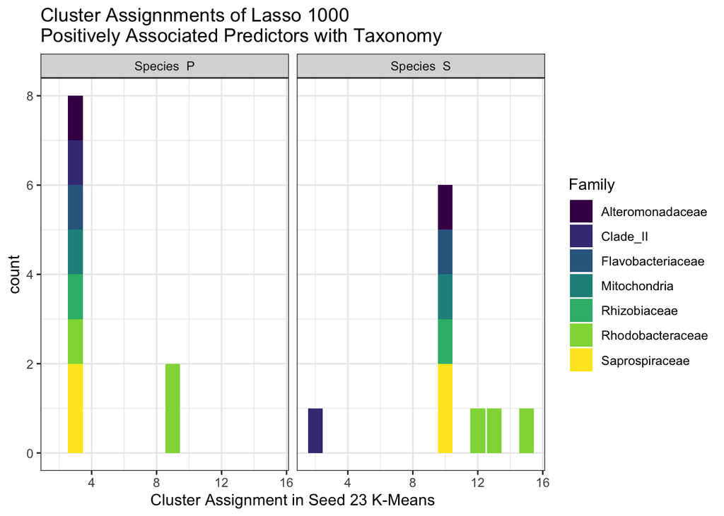

```r
# begin plots for positive coefficients
positive_lasso %>%
  ggplot(aes(x = seed23_run2, fill = Family)) +
  geom_histogram(stat = 'count') +
  viridis::scale_fill_viridis(discrete = T) +
  theme_bw() +
  xlab("Cluster Assignment in Seed 23 K-Means") +
  ggtitle("Cluster Assignnments of Lasso 1000 \nPositively Associated Predictors with Taxonomy") +
  facet_wrap(~paste("Species ", coral_species))
```

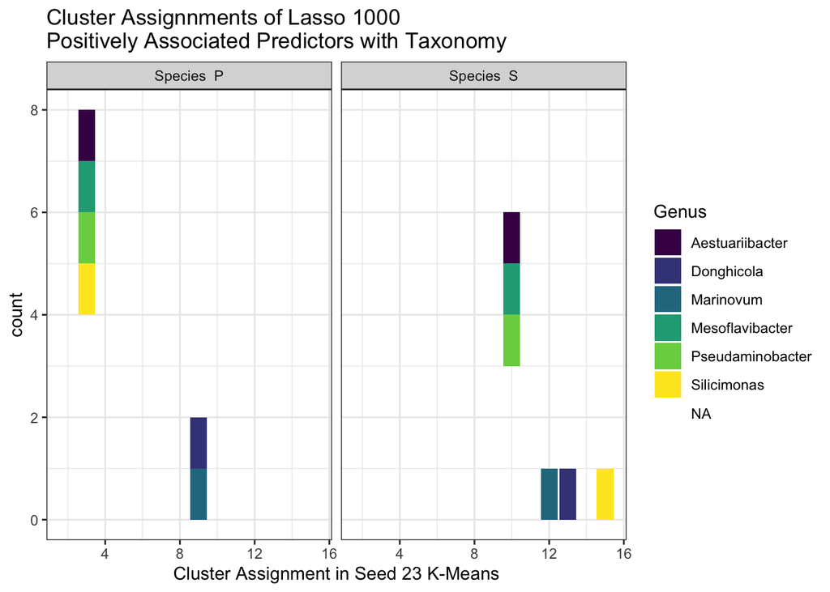

```r
positive_lasso %>%
  ggplot(aes(x = seed23_run2, fill = Genus)) +
  geom_histogram(stat = 'count') +
  viridis::scale_fill_viridis(discrete = T) +
  theme_bw() +
  xlab("Cluster Assignment in Seed 23 K-Means") +
  ggtitle("Cluster Assignnments of Lasso 1000 \nPositively Associated Predictors with Taxonomy") +
  facet_wrap(~paste("Species ", coral_species))
```

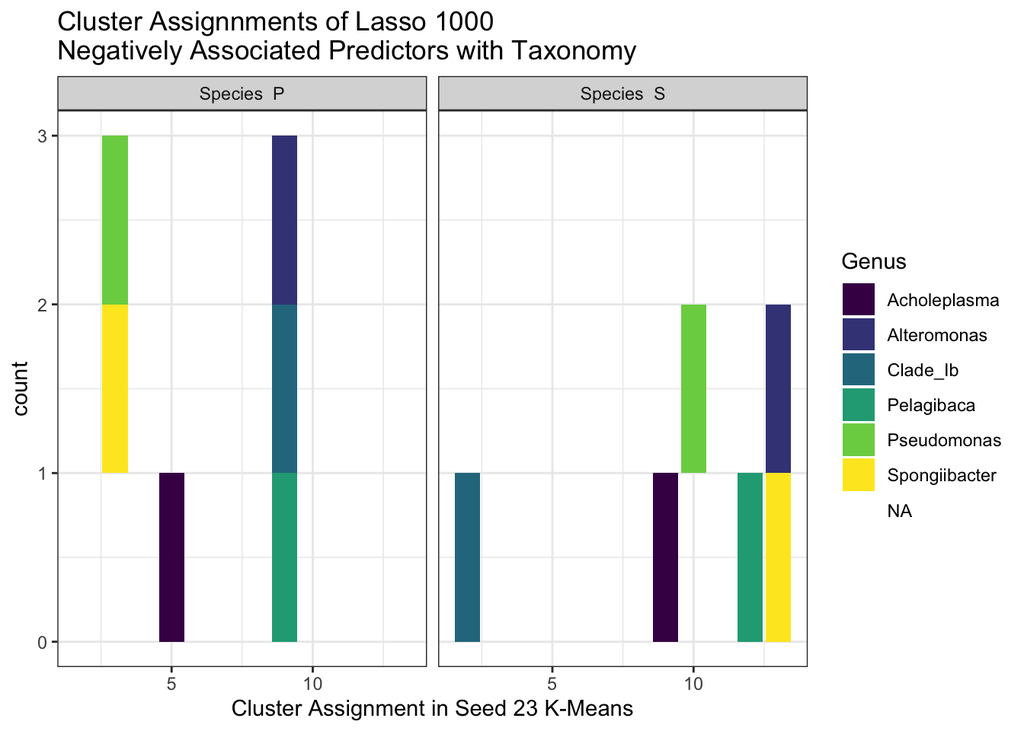

```r
predictors_clade_c_lasso %>%
  arrange(-s1) %>% # highest positive to lowest negative magnitude
# how many are positive coefficients?
  filter(s1 < 0) -> negative_lasso

# begin plots for neg associated predictors
negative_lasso %>%
  ggplot(aes(x = seed23_run2, fill = Genus)) +
  geom_histogram(stat = 'count') +
  viridis::scale_fill_viridis(discrete = T) +
  theme_bw() +
  xlab("Cluster Assignment in Seed 23 K-Means") +
  ggtitle("Cluster Assignnments of Lasso 1000 \nNegatively Associated Predictors with Taxonomy") +
  facet_wrap(~paste("Species ", coral_species))
```

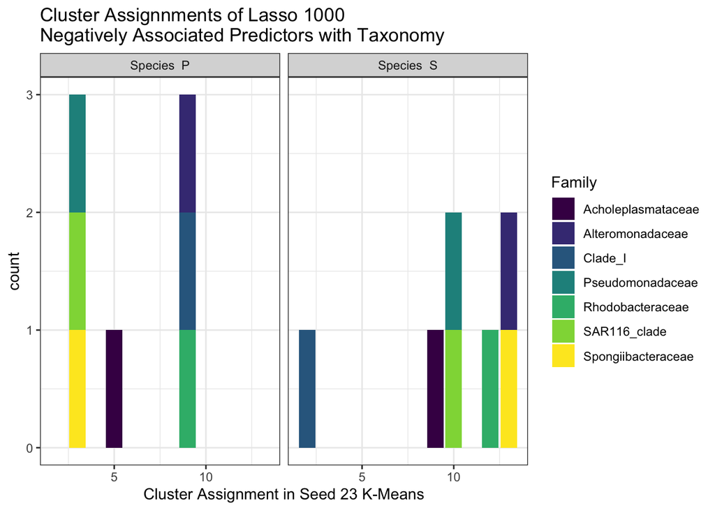

```r
negative_lasso %>%
  ggplot(aes(x = seed23_run2, fill = Family)) +
  geom_histogram(stat = 'count') +
  viridis::scale_fill_viridis(discrete = T) +
  theme_bw() +
  xlab("Cluster Assignment in Seed 23 K-Means") +
  ggtitle("Cluster Assignnments of Lasso 1000 \nNegatively Associated Predictors with Taxonomy") +
  facet_wrap(~paste("Species ", coral_species))
```

# Plots - Showing for “Best” Model of Lasso 1000

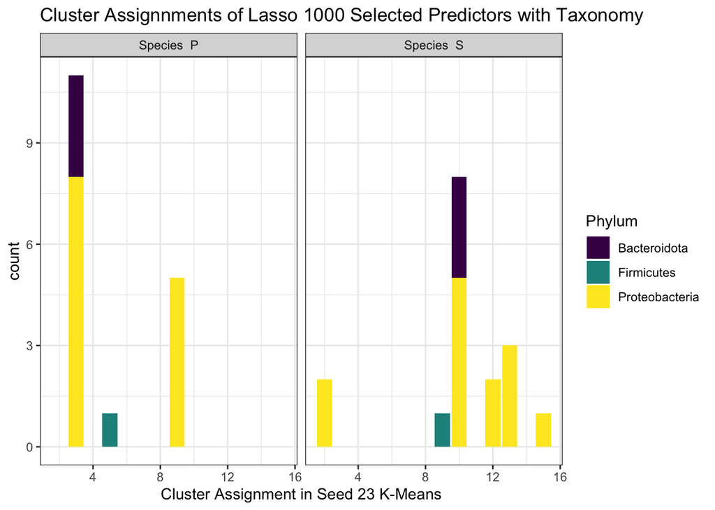

```r
predictors_clade_c_lasso %>%
  ggplot(aes(x = seed23_run2, fill = Phylum)) +
  geom_histogram(stat = 'count') +
  viridis::scale_fill_viridis(discrete = T) +
  theme_bw() +
  xlab("Cluster Assignment in Seed 23 K-Means") +
  ggtitle("Cluster Assignnments of Lasso 1000 Selected Predictors with Taxonomy") +
  facet_wrap(~paste("Species ", coral_species))
```

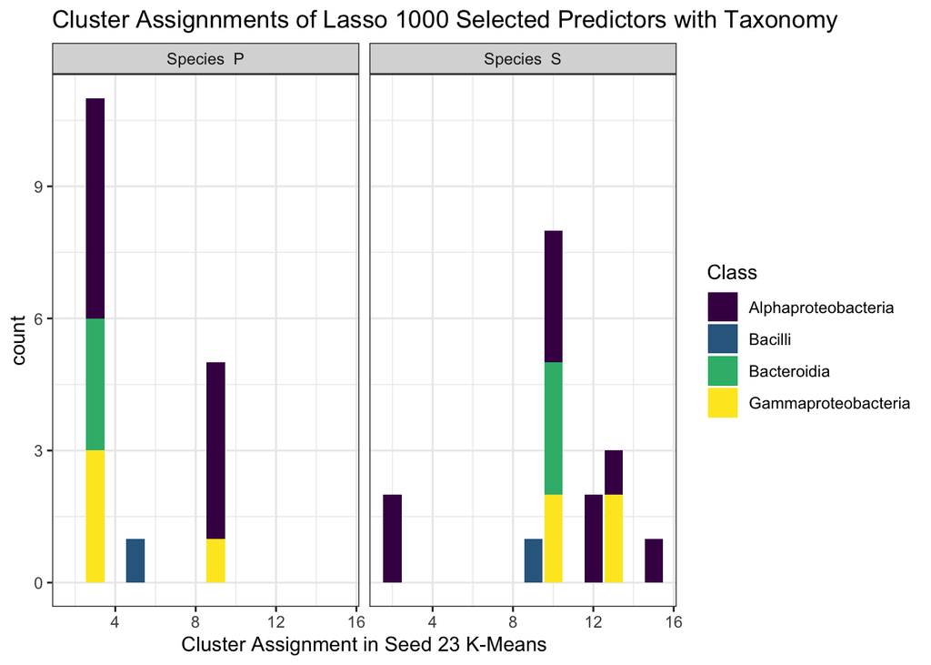

```r
predictors_clade_c_lasso %>%
  ggplot(aes(x = seed23_run2, fill = Class)) +
  geom_histogram(stat = 'count') +
  viridis::scale_fill_viridis(discrete = T) +
  theme_bw() +
  xlab("Cluster Assignment in Seed 23 K-Means") +
  ggtitle("Cluster Assignnments of Lasso 1000 Selected Predictors with Taxonomy") +
  facet_wrap(~paste("Species ", coral_species))
```

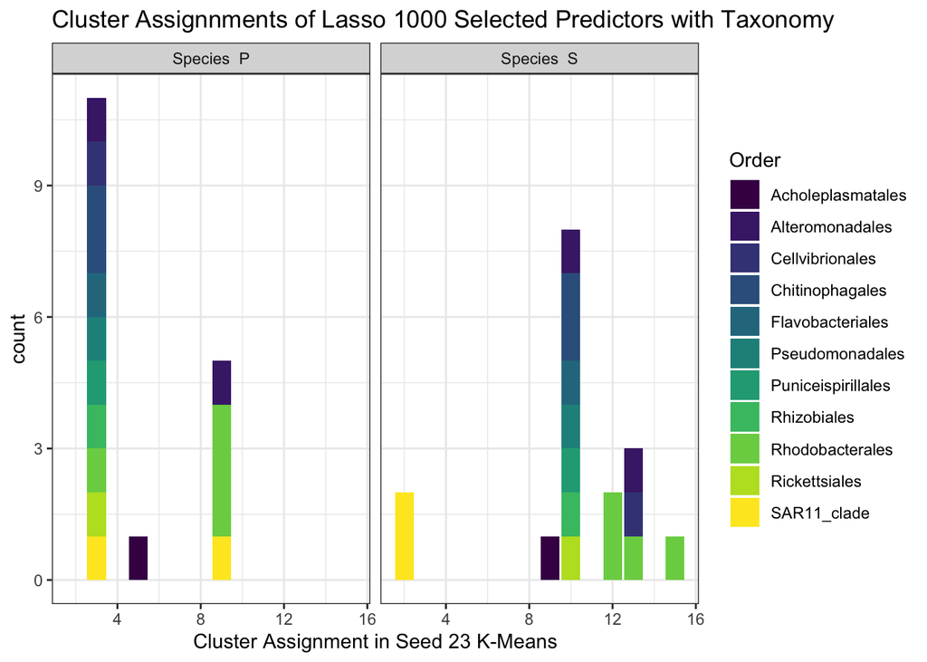

```r
predictors_clade_c_lasso %>%
  ggplot(aes(x = seed23_run2, fill = Order)) +
  geom_histogram(stat = 'count') +
  viridis::scale_fill_viridis(discrete = T) +
  theme_bw() +
  xlab("Cluster Assignment in Seed 23 K-Means") +
  ggtitle("Cluster Assignnments of Lasso 1000 Selected Predictors with Taxonomy") +
  facet_wrap(~paste("Species ", coral_species))
```

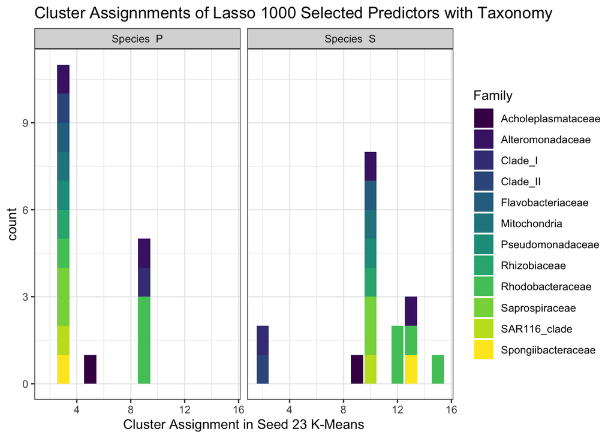

```r
predictors_clade_c_lasso %>%
  ggplot(aes(x = seed23_run2, fill = Family)) +
  geom_histogram(stat = 'count') +
  viridis::scale_fill_viridis(discrete = T) +
  theme_bw() +
  xlab("Cluster Assignment in Seed 23 K-Means") +
  ggtitle("Cluster Assignnments of Lasso 1000 Selected Predictors with Taxonomy") +
  facet_wrap(~paste("Species ", coral_species))
```

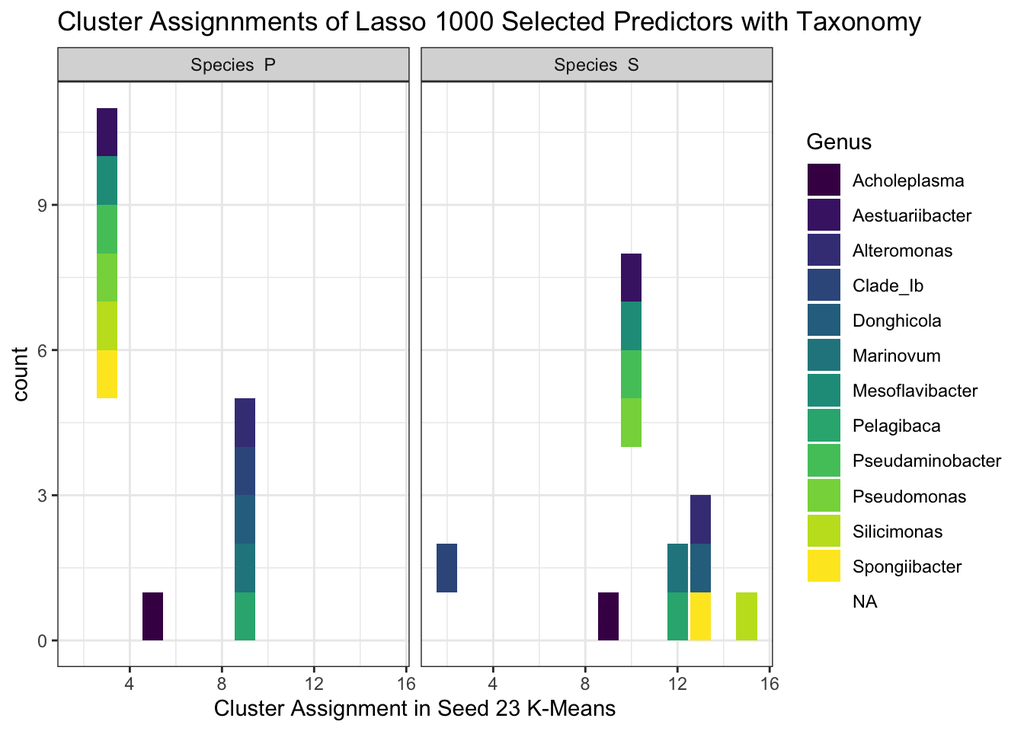

```r
predictors_clade_c_lasso %>%
  ggplot(aes(x = seed23_run2, fill = Genus)) +
  geom_histogram(stat = 'count') +
  viridis::scale_fill_viridis(discrete = T) +
  theme_bw() +
  xlab("Cluster Assignment in Seed 23 K-Means") +
  ggtitle("Cluster Assignnments of Lasso 1000 Selected Predictors with Taxonomy") +
  facet_wrap(~paste("Species ", coral_species))
```

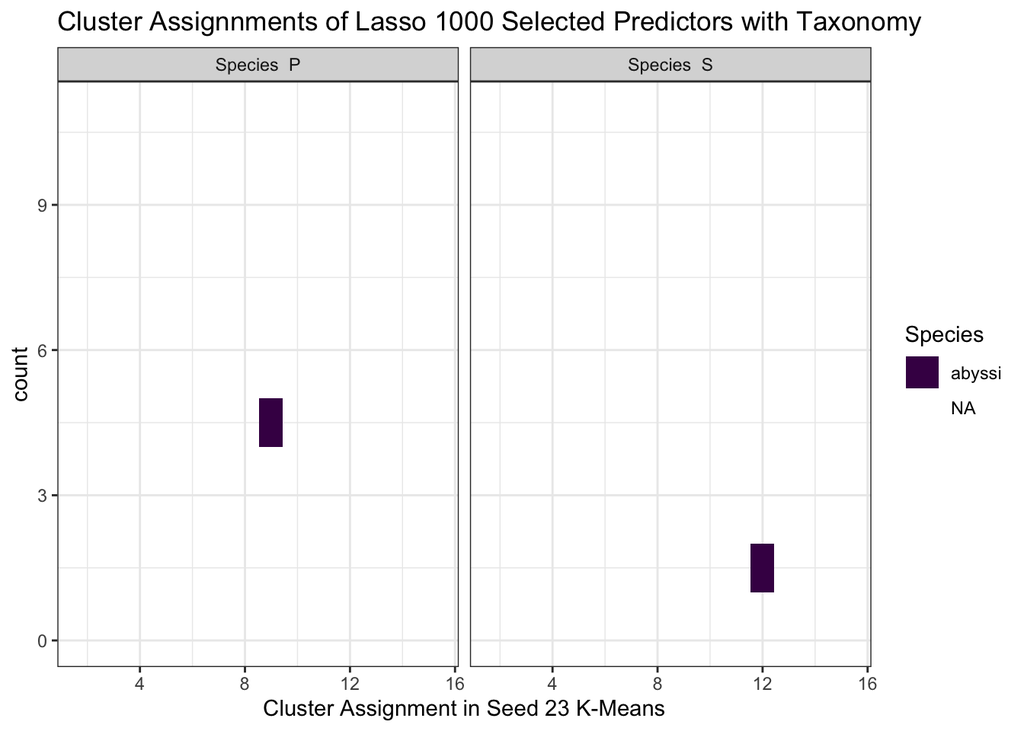

```r
#do not use - most do not have species
predictors_clade_c_lasso %>%
  ggplot(aes(x = seed23_run2, fill = Species)) +
  geom_histogram(stat = 'count') +
  viridis::scale_fill_viridis(discrete = T) +
  theme_bw() +
  xlab("Cluster Assignment in Seed 23 K-Means") +
  ggtitle("Cluster Assignnments of Lasso 1000 Selected Predictors with Taxonomy") +
  facet_wrap(~paste("Species ", coral_species))
```

```r
#
# ggsave(plot = plot_family, "../plots/plot_family.png",
#        width = 12)
#
# gridExtra::grid.arrange(plot_phylum, plot_class,plot_order ,plot_family, plot_genus, ncol = 3) -> five_plots
#
# # Save the combined plots to a PDF file using ggsave
# ggsave("../plots/five_plots.pdf", five_plots, width = 17, height = 11, device = "pdf")
```

- Client would like to use Genus level and Family level plots in final report.

Observations:

- In species P, which was genetically different from species S, the clustering is mostly in cluster 3.
- For species S, which was more genetically diverse, the clustering was more variable but mostly in cluster 10.

# Ridge 200

[figure not shown]

```r
# species P
ridge_coefs[3] %>% # Ridge 200
  as.data.frame() %>%
  filter(str_detect(predictor, "ASV")) %>%
  left_join(clusters_P, join_by("predictor" == "ASV")) %>%
  left_join(bac_tax, join_by("predictor" == "ASV")) %>%
  group_by(Family, Genus) %>%  # 16 groups
  ungroup() %>%
  mutate(coral_species = "P") -> predictors_p_df


# species S
ridge_coefs[3]  %>%
  as.data.frame() %>%
  filter(str_detect(predictor, "ASV")) %>%
  left_join(clusters_S, join_by("predictor" == "ASV")) %>%
  left_join(bac_tax, join_by("predictor" == "ASV")) %>%
  group_by(Family, Genus) %>%  # 16 groups
  ungroup() %>%
  mutate(coral_species = "S") -> predictors_s_df


# combine
bind_rows(
predictors_p_df,
predictors_s_df) -> predictors_clade_c_ridge # genus or family are best per client.


# predictor cluster assignments from ridge 200
predictors_clade_c_ridge %>%
  ggplot(aes(x = seed23_run2, fill = Family)) +
  geom_histogram(stat = 'count') +
  viridis::scale_fill_viridis(discrete = T) +
  theme_bw() +
  xlab("Cluster Assignment in Seed 23 K-Means") +
  ggtitle("Cluster Assignnments of Ridge 200 Predictors with Taxonomy") +
  facet_wrap(~paste("Species ", coral_species))
```

[figure not shown]

```r
predictors_clade_c_ridge %>%
  ggplot(aes(x = seed23_run2, fill = Genus)) +
  geom_histogram(stat = 'count') +
  viridis::scale_fill_viridis(discrete = T) +
  theme_bw() +
  xlab("Cluster Assignment in Seed 23 K-Means") +
  ggtitle("Cluster Assignnments of Ridge 200 Predictors with Taxonomy") +
  facet_wrap(~paste("Species ", coral_species))
```